# Data exploration

François Delavy

3/11/2021

## Overview of the dataset

The dataset consists of 272 observations (rows) and 98 columns. Each column is a question. We will have to think about how to handles all the columns that are a coding language.

The count of NAs by column:

```r
# glimpse(raw_data)

raw_data %>%
  select(everything()) %>%
  summarise_all(list(~ sum(is.na(.)))) %>%
  t() %>%
  kable(format = "html")
```

| ID | 0 |
| --- | --- |
| Start time | 0 |
| Completion time | 0 |
| Email | 0 |
| Name | 272 |
| Which of the following options best describes you today? Here, by “developer” we mean someone who writes code. | 0 |
| Do you code as a hobby? | 0 |
| Which of the following best describes your current employment status? | 0 |
| In which region do you live? | 0 |
| In which city or town do you live? | 0 |
| How old are you? | 0 |
| How frequently do you learn a new language or framework? | 39 |
| C | 220 |
| C# | 211 |
| C++ | 204 |
| HTML/CSS | 76 |
| Java | 166 |
| JavaScript | 88 |
| Kotlin | 228 |
| PHP | 154 |
| Python | 102 |
| Ruby | 243 |
| SQL | 124 |
| Swift | 236 |
| TypeScript | 189 |
| Android | 148 |
| Arduino | 215 |
| AWS | 179 |
| Docker | 199 |
| Google Cloud Platform | 189 |
| Heroku | 184 |

[output cut: 67 more lines]

## Each question/column in more details

Aim: see if some cleaning is needed, get an understanding of what the data is/mean.

The ID starts at 6. Check with Hamzah that we have all the data?

```r
raw_data$ID
```

```
##   [1]   6   7   8   9  10  11  12  13  14  15  16  17  18  19  20  21  22
##  [18]  23  24  25  26  27  28  29  30  31  32  33  34  35  36  37  38  39
##  [35]  40  41  42  43  44  45  46  47  48  49  50  51  52  53  54  55  56
##  [52]  57  58  59  60  61  62  63  64  65  66  67  68  69  70  71  72  73
##  [69]  74  75  76  77  78  79  80  81  82  83  84  85  86  87  88  89  90
##  [86]  91  92  93  94  95  96  97  98  99 100 101 102 103 104 105 106 107
## [103] 108 109 110 111 112 113 114 115 116 117 118 119 120 121 122 123 124
## [120] 125 126 127 128 129 130 131 132 133 134 135 136 137 138 139 140 141
## [137] 142 143 144 145 146 147 148 149 150 151 152 153 154 155 156 157 158
## [154] 159 160 161 162 163 164 165 166 167 168 169 170 171 172 173 174 175
## [171] 176 177 178 179 180 181 182 183 184 185 186 187 188 189 190 191 192
## [188] 193 194 195 196 197 198 199 200 201 202 203 204 205 206 207 208 209
## [205] 210 211 212 213 214 215 216 217 218 219 220 221 222 223 224 225 226
## [222] 227 228 229 230 231 232 233 234 235 236 237 238 239 240 241 242 243
## [239] 244 245 246 247 248 249 250 251 252 253 254 255 256 257 258 259 260
## [256] 261 262 263 264 265 266 267 268 269 270 271 272 273 274 275 276 277
```

The time looks good, not sure if interesting information for us, though.

```r
raw_data$`Start time` %>% head()
```

```
## [1] "2020-10-15 09:13:45 UTC" "2020-10-15 09:16:07 UTC"
## [3] "2020-10-15 09:20:53 UTC" "2020-10-15 09:12:06 UTC"
## [5] "2020-10-15 09:23:29 UTC" "2020-10-15 09:24:23 UTC"
```

```r
raw_data$`Completion time`  %>% head()
```

```
## [1] "2020-10-15 09:24:31 UTC" "2020-10-15 09:25:39 UTC"
## [3] "2020-10-15 09:29:42 UTC" "2020-10-15 09:30:56 UTC"
## [5] "2020-10-15 09:33:27 UTC" "2020-10-15 09:39:03 UTC"
```

**TODO: delete the Name and email**

```r
raw_data$Email %>% head()
```

```
## [1] "anonymous" "anonymous" "anonymous" "anonymous" "anonymous" "anonymous"
```

```r
raw_data$Name %>% head()
```

```
## [1] NA NA NA NA NA NA
```

**TODO: We may want to group some of those in the visualizations?**

```r
raw_data %>%
  group_by(`Which of the following options best describes you today? Here, by "developer" we mean someone who writes code.`) %>%
  tally() %>%
  arrange(-n) %>%
  kable()
```

| Which of the following options best describes you today? Here, by “developer” we mean someone who writes code. | n |
| --- | --- |
| I am a developer by profession | 129 |
| I am a student who is learning to code | 80 |
| I am not primarily a developer, but I write code sometimes as part of my work | 26 |
| I code primarily as a hobby | 20 |
| I used to be a developer by profession, but no longer am | 5 |
| None of these | 5 |
| A Developer | 1 |
| Currently in Transition to Dveloper | 1 |
| I am a business admin student learning how to code both as a hobby and towards a career. | 1 |
| I am a developer and a student | 1 |
| I am studying to occupy a data scientist role | 1 |
| I want to keanr how to cods | 1 |
| I work closely with Developers | 1 |

```r
raw_data %>%
  group_by(`Do you code as a hobby?`) %>%
  tally() %>%
  arrange(-n) %>%
  kable()
```

| Do you code as a hobby? | n |
| --- | --- |
| Yes | 191 |
| No | 81 |

**TODO Some cleaning needed, e.g. National sService**

```r
raw_data %>%
  group_by(`Which of the following best describes your current employment status?` ) %>%
  tally() %>%
  arrange(-n) %>%
  kable()
```

| Which of the following best describes your current employment status? | n |
| --- | --- |
| Employed full-time | 103 |
| Student | 63 |
| Not employed, but looking for work | 41 |
| Independent contractor, freelancer, or self-employed | 37 |
| Employed part-time | 20 |
| National Service Personnel | 2 |
| Both student and a part time worker | 1 |
| I prefer not to say | 1 |
| I run my own business | 1 |
| National service | 1 |
| National Service | 1 |
| Student and working | 1 |

Looks clean, see [map](https://en.wikipedia.org/wiki/Regions_of_Ghana#/media/File:Ghana,_administrative_divisions_2018_-_de_-_colored.svg). Will need to decide what to do with respondents outside of Ghana (e.g. group them?).

```r
raw_data %>%
  group_by(`In which region do you live?`) %>%
  tally() %>%
  arrange(-n) %>%
  kable()
```

| In which region do you live? | n |
| --- | --- |
| Greater Accra Region | 186 |
| Ashanti Region | 32 |
| Eastern Region | 13 |
| Northern Region | 10 |
| Volta Region | 9 |
| Central Region | 8 |
| Upper West Region | 4 |
| Bono East Region | 2 |
| Western Region | 2 |
| Ahafo Region | 1 |
| From Ghana but live outside Ghana | 1 |
| India | 1 |
| Outside Ghana | 1 |
| Upper East Region | 1 |
| USA | 1 |

**TODO: some cleaning needed, e.g. Accra, Ho, Tema, …**  
Note: if we want a map, we could use together with the region to geolocalize

```r
raw_data %>%
  group_by(`In which city or town do you live?`) %>%
  tally() %>%
  kable()
```

| In which city or town do you live? | n |
| --- | --- |
| Ablekuma | 5 |
| Ablekuma Fanmilk | 1 |
| accra | 1 |
| Accra | 59 |
| ACCRA | 1 |
| Accra - Ashaley Botwe | 1 |
| Accra (lapaz) | 1 |
| Accra, Ashongman | 1 |
| Accra, Sowutuom | 1 |
| Accra, Spintex | 1 |
| Achimota | 2 |
| Ada-Foah | 1 |
| Adabraka | 2 |
| Adenta | 8 |
| Adenta municipality | 1 |
| Adenta New Legon | 1 |
| Aflao | 1 |
| Airport West Residential Area, Accra | 1 |
| Ajiringanor | 1 |
| Akatsi | 1 |
| Akosombo | 1 |
| Akuse | 1 |
| Amanfrom | 1 |
| Amasaman | 3 |
| Aplaku New weija | 1 |
| Ashaiman | 2 |
| Ashaley Botwe | 2 |
| Ashiaman | 1 |
| Ashiyie | 2 |
| Awomaso | 1 |

[output cut: 84 more lines]

TODO: probably convertt to factor and set order.

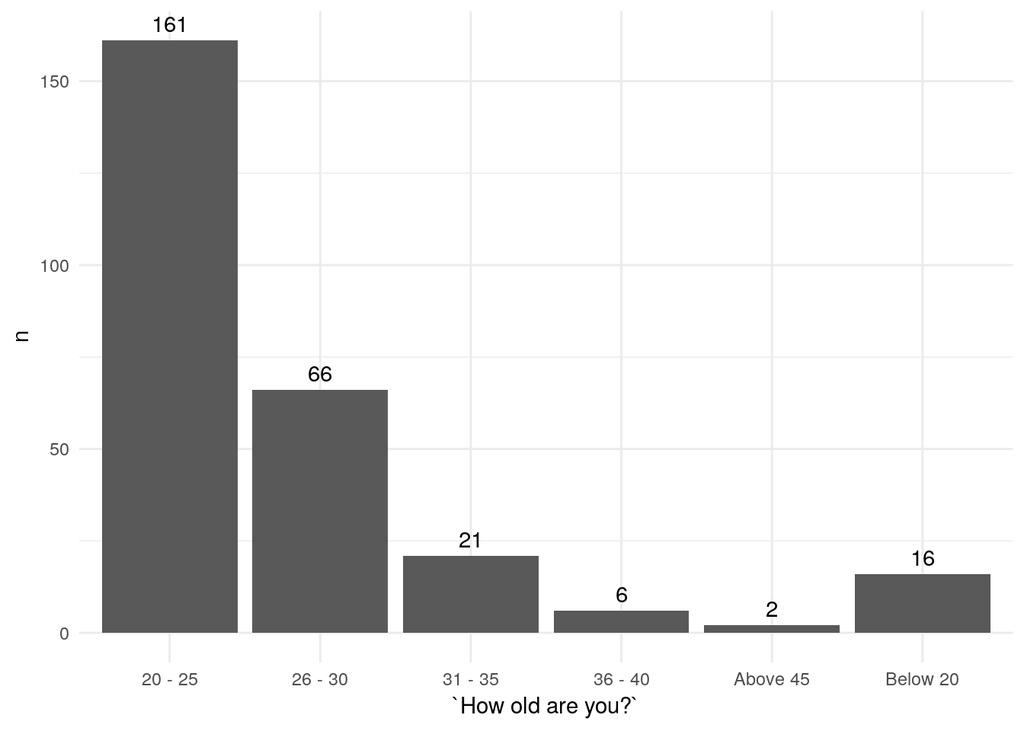

```r
raw_data %>%
  group_by(`How old are you?`) %>%
  tally() %>%
  ggplot(aes(x=`How old are you?`, y=n)) +
  geom_col() +
  theme_minimal() +
  geom_text(aes(label = n), vjust = -0.5)
```

TODO: need to take some decision on how to group the catetgories for plots

```r
raw_data %>%
  group_by(`How frequently do you learn a new language or framework?`) %>%
  tally() %>%
  arrange(-n) %>%
  kable()
```

[output not shown]

```r
raw_data %>%
  group_by(C) %>%
  tally() %>%
  arrange(-n) %>%
  kable()
```

| C | n |
| --- | --- |
| NA | 220 |
| Worked with in PAST year | 29 |
| Want to work with NEXT year | 16 |
| Both | 7 |

```r
raw_data %>%
  group_by(`If there are any other technologies you've worked with this year or plan to work with next year that were not listed, please list them as follows, separated by commas. \r\n\r\neg. JavaScript - this year...`) %>%
  tally() %>%
  arrange(-n) %>%
  kable()
```

If there are any other technologies you’ve worked with this year or plan to work with next year that were not listed, please list them as follows, separated by commas.

| eg. JavaScript - this year… n |  |
| --- | --- |
| NA | 207 |
| Golang - next year | 4 |
| Python | 4 |
| Golang | 3 |
| Golang - both | 3 |
| Python-both | 2 |
| Asana - both | 1 |
| Bash shell script - both, rust - next year | 1 |
| Blockchain - next year | 1 |
| Elixir - this both, Golang- both | 1 |
| Ethical Hacking - next year | 1 |
| FastAPI | 1 |
| Firebase - both | 1 |
| Flask | 1 |
| Flask-both | 1 |
| Flask-Restful - both | 1 |
| Golang - both |  |
| ocaml - both |  |
| blockchain -both 1 |  |
| Golang - next year , AWS - next year , Google Cloud Platform - next year , Android - next year , IOS - next year | 1 |
| Golang - next year, python - next year | 1 |
| Golang, Ocaml, Rust, Haskell, ML/AI | 1 |
| HTML | 1 |
| Javascript | 1 |
| JavaScript | 1 |
| JavaScript - both | 1 |
| JavaScript - both |  |
| Python - next year 1 |  |
| Javascript - next year, python - both, c++-both | 1 |
| Javascript -both, java/kotlin -both, python -both, | 1 |
| JavaScript , python | 1 |
| JavaScript, React Js, React native, HTML, CSS, Flask | 1 |
| Lua | 1 |
| Lua - both | 1 |
| MATLAB - Both | 1 |
| Nodejs - next year | 1 |
| None | 1 |
| Python - both | 1 |
| Python - both |  |
| JavaScript - next year 1 |  |
| python - this year | 1 |
| Python -both | 1 |
| Python and Solidity - this year |  |
| JavaScript-next year 1 |  |
| Python Flask- Both | 1 |
| Python- this year , Ruby- next year | 1 |
| Python-this year | 1 |
| Python, Angular, Vue - Next Year |  |
| AI, Intelligent Apps - Some Few Years To Come 1 |  |
| Python, IoT,AI | 1 |
| python, JavaScript | 1 |
| Qt - both, Golang - next year | 1 |
| R | 1 |
| Rust - This year | 1 |
| Sails,js - both | 1 |
| Scala -both, Golang-next year. | 1 |
| Sckitlearn, R, | 1 |
| Selenium - both | 1 |
| Unity - both, Python - next year | 1 |
| Unity3D - both, Godot - next year | 1 |
| XD-this year | 1 |

```r
raw_data %>%
  group_by(`In which operating system would you rather work?`) %>%
  tally() %>%
  arrange(-n) %>%
  kable()
```

| In which operating system would you rather work? | n |
| --- | --- |
| MacOS | 88 |
| Windows | 84 |
| Linux-based | 83 |
| NA | 16 |
| BSD | 1 |

```r
raw_data %>%
  group_by(`What level of influence do you, personally, have over new technology purchases at your organization?` ) %>%
  tally() %>%
  arrange(-n) %>%
  kable()
```

| What level of influence do you, personally, have over new technology purchases at your organization? | n |
| --- | --- |
| I have little or no influence | 105 |
| I have a great deal of influence | 81 |
| I have some influence | 68 |
| NA | 18 |

We will need to handle this once we decide what/how to plot:

```r
raw_data %>%
  group_by(`When buying a new tool or software, how do you discover and research available solutions? Select all that apply.`) %>%
  tally() %>%
  arrange(-n) %>%
  kable()
```

| When buying a new tool or software, how do you discover and research available solutions? Select all that apply. | n |
| --- | --- |
| Start a free trial; | 49 |
| Start a free trial;Ask developers I know/work with; | 20 |
| Start a free trial;Ask developers I know/work with;Visit developer communities like Stack Overflow;Read ratings or reviews on third party siteslike G2Crowd; | 20 |
| Ask developers I know/work with; | 19 |
| Start a free trial;Ask developers I know/work with;Visit developer communities like Stack Overflow; | 16 |
| Visit developer communities like Stack Overflow; | 12 |
| Start a free trial;Ask developers I know/work with;Read ratings or reviews on third party siteslike G2Crowd; | 11 |
| Ask developers I know/work with;Start a free trial; | 10 |
| Ask developers I know/work with;Visit developer communities like Stack Overflow; | 10 |
| Ask developers I know/work with;Visit developer communities like Stack Overflow;Read ratings or reviews on third party siteslike G2Crowd; | 10 |
| NA | 10 |
| Ask developers I know/work with;Read ratings or reviews on third party siteslike G2Crowd; | 5 |
| Ask developers I know/work with;Visit developer communities like Stack Overflow;Start a free trial; | 5 |
| Read ratings or reviews on third party siteslike G2Crowd; | 5 |
| Visit developer communities like Stack Overflow;Ask developers I know/work with; | 5 |
| Visit developer communities like Stack Overflow;Ask developers I know/work with;Start a free trial; | 4 |
| Visit developer communities like Stack Overflow;Start a free trial;Ask developers I know/work with; | 4 |
| Ask developers I know/work with;Read ratings or reviews on third party siteslike G2Crowd;Start a free trial; | 3 |
| Ask developers I know/work with;Start a free trial;Visit developer communities like Stack Overflow; | 3 |
| Ask developers I know/work with;Visit developer communities like Stack Overflow;Read ratings or reviews on third party siteslike G2Crowd;Start a free trial; | 3 |
| Read ratings or reviews on third party siteslike G2Crowd;Start a free trial; | 3 |
| Start a free trial;Visit developer communities like Stack Overflow; | 3 |
| Start a free trial;Visit developer communities like Stack Overflow;Ask developers I know/work with;Read ratings or reviews on third party siteslike G2Crowd; | 3 |
| Start a free trial;Visit developer communities like Stack Overflow;Read ratings or reviews on third party siteslike G2Crowd; | 3 |
| Visit developer communities like Stack Overflow;Start a free trial; | 3 |
| Ask developers I know/work with;Read ratings or reviews on third party siteslike G2Crowd;Visit developer communities like Stack Overflow; | 2 |
| Read ratings or reviews on third party siteslike G2Crowd;Ask developers I know/work with; | 2 |
| Visit developer communities like Stack Overflow;Read ratings or reviews on third party siteslike G2Crowd; | 2 |
| Visit developer communities like Stack Overflow;Read ratings or reviews on third party siteslike G2Crowd;Ask developers I know/work with; | 2 |
| Ask developers I know/work with;Start a free trial;Read ratings or reviews on third party siteslike G2Crowd; | 1 |
| Ask developers I know/work with;Start a free trial;Read ratings or reviews on third party siteslike G2Crowd;Visit developer communities like Stack Overflow; | 1 |
| Ask developers I know/work with;Start a free trial;Visit developer communities like Stack Overflow;Read ratings or reviews on third party siteslike G2Crowd; | 1 |
| Depends on the use case; | 1 |
| Read ratings or reviews on third party siteslike G2Crowd;Ask developers I know/work with;Start a free trial;Visit developer communities like Stack Overflow; | 1 |
| Read ratings or reviews on third party siteslike G2Crowd;Ask developers I know/work with;Visit developer communities like Stack Overflow; | 1 |
| Read ratings or reviews on third party siteslike G2Crowd;Visit developer communities like Stack Overflow; | 1 |
| Read ratings or reviews on third party siteslike G2Crowd;Visit developer communities like Stack Overflow;Ask developers I know/work with; | 1 |
| Read ratings or reviews on third party siteslike G2Crowd;Visit developer communities like Stack Overflow;Start a free trial; | 1 |
| Start a free trial;Ask developers I know/work with;Visit developer communities like Stack Overflow;Read ratings or reviews on third party siteslike G2Crowd;I contact solutions support staff ; | 1 |
| Start a free trial;Ask developers I know/work with;Visit developer communities like Stack Overflow;Read ratings or reviews on third party siteslike G2Crowd;YouTube Videos; | 1 |
| Start a free trial;Read ratings or reviews on third party siteslike G2Crowd; | 1 |
| Start a free trial;Read ratings or reviews on third party siteslike G2Crowd;Ask developers I know/work with; | 1 |
| Start a free trial;Read ratings or reviews on third party siteslike G2Crowd;Ask developers I know/work with;Visit developer communities like Stack Overflow; | 1 |
| Start a free trial;Visit developer communities like Stack Overflow;Ask developers I know/work with; | 1 |
| Start a free trial;Visit developer communities like Stack Overflow;Ask developers I know/work with;Read ratings or reviews on third party siteslike G2Crowd;Read a documentary of that software ; | 1 |
| Start a free trial;Visit developer communities like Stack Overflow;Read ratings or reviews on third party siteslike G2Crowd;Ask developers I know/work with; | 1 |
| Visit developer communities like Stack Overflow;Ask developers I know/work with;Read ratings or reviews on third party siteslike G2Crowd; | 1 |
| Visit developer communities like Stack Overflow;Read ratings or reviews on third party siteslike G2Crowd;Ask developers I know/work with;Start a free trial; | 1 |
| Visit developer communities like Stack Overflow;Read ratings or reviews on third party siteslike G2Crowd;Start a free trial; | 1 |
| Visit developer communities like Stack Overflow;Read ratings or reviews on third party siteslike G2Crowd;Start a free trial;Ask developers I know/work with; | 1 |
| Visit developer communities like Stack Overflow;Start a free trial;Ask developers I know/work with;Read ratings or reviews on third party siteslike G2Crowd; | 1 |
| Visit developer communities like Stack Overflow;Start a free trial;Read ratings or reviews on third party siteslike G2Crowd; | 1 |
| Visit developer communities like Stack Overflow;Start a free trial;Read ratings or reviews on third party siteslike G2Crowd;Ask developers I know/work with; | 1 |
| YouTube ; | 1 |

```r
raw_data %>%
  group_by(`Which of the following best describes the highest level of formal education that you have completed?`) %>%
  tally() %>%
  arrange(-n) %>%
  kable()
```

| Which of the following best describes the highest level of formal education that you have completed? | n |
| --- | --- |
| Bachelor’s degree | 171 |
| Secondary school | 45 |
| NA | 28 |
| Master’s degree | 10 |
| HND | 4 |
| Diploma | 2 |
| Higher National Diploma | 2 |
| Professional degree | 2 |
| Advanced National Diploma | 1 |
| College | 1 |
| Diploma in Basic Education | 1 |
| Higher National Diploma (HND) | 1 |
| Professional Diploma | 1 |
| Still in shs | 1 |
| Still in the University | 1 |
| Will finish bachelor’s degree in 2021 | 1 |

…

```r
raw_data %>%
  group_by(`How frequently do you learn a new language or framework?`) %>%
  tally() %>%
  kable()
```

| How frequently do you learn a new language or framework? | n |
| --- | --- |
| As and when it’s necessary for a project | 1 |
| As needed for work and research | 1 |
| Every few months | 128 |
| I don’t remember the last time | 1 |
| I started learning not long ago and so far I’ve learnt only one language. | 1 |
| i stick to a selected few. | 1 |
| Once a decade | 1 |
| Once a year | 60 |
| Once every few years | 31 |
| Project dependent | 1 |
| Usually not…stuck with python for a long time now | 1 |
| When I feel the need to | 1 |
| When i have someone to help me learn it | 1 |
| When Neccessary | 1 |
| When the need arises | 1 |
| When there is a need to | 1 |
| When work requires it | 1 |
| NA | 39 |

**TODO: some cleaning needed, e.g. When Neccessary,When there is a need to, …**  
Note: maybe we can group them in other ways

**TODO: The Variable ’If there are any other technologies you’ve worked with this year or plan to work with next year that were not listed, please list them as follows, separated by commas.**

**eg. JavaScript - this year…’**  
needs to be renamed

```r
raw_data %>%
  group_by(`What is the primary operating system in which you work?`) %>%
  tally() %>%
  kable()
```

| What is the primary operating system in which you work? | n |
| --- | --- |
| BSD | 1 |
| Linux-based | 39 |
| MacOS | 41 |
| Windows | 188 |
| NA | 3 |

```r
raw_data %>%
  group_by(`In which operating system would you rather work?`) %>%
  tally() %>%
  kable()
```

| In which operating system would you rather work? | n |
| --- | --- |
| BSD | 1 |
| Linux-based | 83 |
| MacOS | 88 |
| Windows | 84 |
| NA | 16 |

```r
raw_data %>%
  group_by(`What level of influence do you, personally, have over new technology purchases at your organization?`) %>%
  tally() %>%
  kable()
```

| What level of influence do you, personally, have over new technology purchases at your organization? | n |
| --- | --- |
| I have a great deal of influence | 81 |
| I have little or no influence | 105 |
| I have some influence | 68 |
| NA | 18 |

```r
raw_data %>%
  group_by(`When buying a new tool or software, how do you discover and research available solutions? Select all that apply.`) %>%
  tally() %>%
  kable()
```

| When buying a new tool or software, how do you discover and research available solutions? Select all that apply. | n |
| --- | --- |
| Ask developers I know/work with; | 19 |
| Ask developers I know/work with;Read ratings or reviews on third party siteslike G2Crowd; | 5 |
| Ask developers I know/work with;Read ratings or reviews on third party siteslike G2Crowd;Start a free trial; | 3 |
| Ask developers I know/work with;Read ratings or reviews on third party siteslike G2Crowd;Visit developer communities like Stack Overflow; | 2 |
| Ask developers I know/work with;Start a free trial; | 10 |
| Ask developers I know/work with;Start a free trial;Read ratings or reviews on third party siteslike G2Crowd; | 1 |
| Ask developers I know/work with;Start a free trial;Read ratings or reviews on third party siteslike G2Crowd;Visit developer communities like Stack Overflow; | 1 |
| Ask developers I know/work with;Start a free trial;Visit developer communities like Stack Overflow; | 3 |
| Ask developers I know/work with;Start a free trial;Visit developer communities like Stack Overflow;Read ratings or reviews on third party siteslike G2Crowd; | 1 |
| Ask developers I know/work with;Visit developer communities like Stack Overflow; | 10 |
| Ask developers I know/work with;Visit developer communities like Stack Overflow;Read ratings or reviews on third party siteslike G2Crowd; | 10 |
| Ask developers I know/work with;Visit developer communities like Stack Overflow;Read ratings or reviews on third party siteslike G2Crowd;Start a free trial; | 3 |
| Ask developers I know/work with;Visit developer communities like Stack Overflow;Start a free trial; | 5 |
| Depends on the use case; | 1 |
| Read ratings or reviews on third party siteslike G2Crowd; | 5 |
| Read ratings or reviews on third party siteslike G2Crowd;Ask developers I know/work with; | 2 |
| Read ratings or reviews on third party siteslike G2Crowd;Ask developers I know/work with;Start a free trial;Visit developer communities like Stack Overflow; | 1 |
| Read ratings or reviews on third party siteslike G2Crowd;Ask developers I know/work with;Visit developer communities like Stack Overflow; | 1 |
| Read ratings or reviews on third party siteslike G2Crowd;Start a free trial; | 3 |
| Read ratings or reviews on third party siteslike G2Crowd;Visit developer communities like Stack Overflow; | 1 |
| Read ratings or reviews on third party siteslike G2Crowd;Visit developer communities like Stack Overflow;Ask developers I know/work with; | 1 |
| Read ratings or reviews on third party siteslike G2Crowd;Visit developer communities like Stack Overflow;Start a free trial; | 1 |
| Start a free trial; | 49 |
| Start a free trial;Ask developers I know/work with; | 20 |
| Start a free trial;Ask developers I know/work with;Read ratings or reviews on third party siteslike G2Crowd; | 11 |
| Start a free trial;Ask developers I know/work with;Visit developer communities like Stack Overflow; | 16 |
| Start a free trial;Ask developers I know/work with;Visit developer communities like Stack Overflow;Read ratings or reviews on third party siteslike G2Crowd; | 20 |
| Start a free trial;Ask developers I know/work with;Visit developer communities like Stack Overflow;Read ratings or reviews on third party siteslike G2Crowd;I contact solutions support staff ; | 1 |
| Start a free trial;Ask developers I know/work with;Visit developer communities like Stack Overflow;Read ratings or reviews on third party siteslike G2Crowd;YouTube Videos; | 1 |
| Start a free trial;Read ratings or reviews on third party siteslike G2Crowd; | 1 |
| Start a free trial;Read ratings or reviews on third party siteslike G2Crowd;Ask developers I know/work with; | 1 |
| Start a free trial;Read ratings or reviews on third party siteslike G2Crowd;Ask developers I know/work with;Visit developer communities like Stack Overflow; | 1 |
| Start a free trial;Visit developer communities like Stack Overflow; | 3 |
| Start a free trial;Visit developer communities like Stack Overflow;Ask developers I know/work with; | 1 |
| Start a free trial;Visit developer communities like Stack Overflow;Ask developers I know/work with;Read ratings or reviews on third party siteslike G2Crowd; | 3 |
| Start a free trial;Visit developer communities like Stack Overflow;Ask developers I know/work with;Read ratings or reviews on third party siteslike G2Crowd;Read a documentary of that software ; | 1 |
| Start a free trial;Visit developer communities like Stack Overflow;Read ratings or reviews on third party siteslike G2Crowd; | 3 |
| Start a free trial;Visit developer communities like Stack Overflow;Read ratings or reviews on third party siteslike G2Crowd;Ask developers I know/work with; | 1 |
| Visit developer communities like Stack Overflow; | 12 |
| Visit developer communities like Stack Overflow;Ask developers I know/work with; | 5 |
| Visit developer communities like Stack Overflow;Ask developers I know/work with;Read ratings or reviews on third party siteslike G2Crowd; | 1 |
| Visit developer communities like Stack Overflow;Ask developers I know/work with;Start a free trial; | 4 |
| Visit developer communities like Stack Overflow;Read ratings or reviews on third party siteslike G2Crowd; | 2 |
| Visit developer communities like Stack Overflow;Read ratings or reviews on third party siteslike G2Crowd;Ask developers I know/work with; | 2 |
| Visit developer communities like Stack Overflow;Read ratings or reviews on third party siteslike G2Crowd;Ask developers I know/work with;Start a free trial; | 1 |
| Visit developer communities like Stack Overflow;Read ratings or reviews on third party siteslike G2Crowd;Start a free trial; | 1 |
| Visit developer communities like Stack Overflow;Read ratings or reviews on third party siteslike G2Crowd;Start a free trial;Ask developers I know/work with; | 1 |
| Visit developer communities like Stack Overflow;Start a free trial; | 3 |
| Visit developer communities like Stack Overflow;Start a free trial;Ask developers I know/work with; | 4 |
| Visit developer communities like Stack Overflow;Start a free trial;Ask developers I know/work with;Read ratings or reviews on third party siteslike G2Crowd; | 1 |
| Visit developer communities like Stack Overflow;Start a free trial;Read ratings or reviews on third party siteslike G2Crowd; | 1 |
| Visit developer communities like Stack Overflow;Start a free trial;Read ratings or reviews on third party siteslike G2Crowd;Ask developers I know/work with; | 1 |
| YouTube ; | 1 |
| NA | 10 |
| **TODO: separate the sentences by semicolon and create a wide format (so it looks the same as the programming languages they use**_ |  |

```r
raw_data %>%
  group_by(`Which of the following best describes the highest level of formal education that you have completed?`) %>%
  tally() %>%
  kable()
```

| Which of the following best describes the highest level of formal education that you have completed? | n |
| --- | --- |
| Advanced National Diploma | 1 |
| Bachelor’s degree | 171 |
| College | 1 |
| Diploma | 2 |
| Diploma in Basic Education | 1 |
| Higher National Diploma | 2 |
| Higher National Diploma (HND) | 1 |
| HND | 4 |
| Master’s degree | 10 |
| Professional degree | 2 |
| Professional Diploma | 1 |
| Secondary school | 45 |
| Still in shs | 1 |
| Still in the University | 1 |
| Will finish bachelor’s degree in 2021 | 1 |
| NA | 28 |

**TODO: ask Hamzah in the next meeting about the education system in Ghana e.g. is advanced and higher national diploma the same? and also professional degree and professional diploma is the same?**

```r
raw_data %>%
  group_by(`How important is a formal education, such as a university degree in computer science, to your career?`) %>%
  tally() %>%
  kable()
```

| How important is a formal education, such as a university degree in computer science, to your career? | n |
| --- | --- |
| Critically important | 36 |
| Fairly important | 74 |
| Not at all important/not necessary | 23 |
| Somewhat important | 27 |
| Very important | 80 |
| NA | 32 |

```r
raw_data %>%
  group_by(`From Q18, if you could go back and change your educational path (but end up in the same career), what would you change?`) %>%
  tally() %>%
  kable()
```

| From Q18, if you could go back and change your educational path (but end up in the same career), what would you change? | n |
| --- | --- |
| Approach to learning | 1 |
| Attend bootcamps | 1 |
| Avoid the norm that Medicine and Pharmacy are the best , rather re-engineered my mind to channel a keen attention on Coding and Computers. The Physics and the E-Maths combined with IT. | 1 |
| Begin professional certifications earlier | 1 |
| Business or graphic design | 1 |
| Change Master’s to Professional Certificates | 1 |
| Change my field of study to computer science | 1 |
| Coding | 1 |
| Combination of modules I select for the course | 1 |
| Commitment | 1 |
| computer science | 1 |
| Computer Science | 2 |
| Computer Science degrees should be mode practical with modern employable languages | 1 |
| CS | 1 |
| Curriculum | 1 |
| Do more mathematics | 1 |
| field of study | 1 |
| Go to a Boot Camp | 1 |
| Going to university. I would rather do certifications straight forward | 1 |
| How I learned programming | 1 |
| How the courses are taught | 1 |
| I will change the course I chose. | 1 |
| I will just add computer science to my program of study | 1 |
| I will still prefer the same educational career | 1 |
| I won’t change | 1 |
| I won’t change a thing | 1 |
| I won’t go to university. | 1 |
| I would change my programme of study to computer science, or software engineering. | 1 |
| I would do more Math | 1 |
| I would have learnt programming alongside the programme I did | 1 |

[output cut: 73 more lines]

```r
raw_data %>%
  group_by(`How satisfied are you with your current job? (If you work multiple jobs, answer for one you spend the most hours on.)`) %>%
  tally() %>%
  kable()
```

| How satisfied are you with your current job? (If you work multiple jobs, answer for one you spend the most hours on.) | n |
| --- | --- |
| Neither satisfied nor dissatisfied | 48 |
| Slightly dissatisfied | 27 |
| Slightly satisfied | 67 |
| Very dissatisfied | 20 |
| Very satisfied | 54 |
| NA | 56 |

```r
raw_data %>%
  group_by(`Approximately how many people are employed by the company or organization you currently work for?`) %>%
  tally() %>%
  kable()
```

| Approximately how many people are employed by the company or organization you currently work for? | n |
| --- | --- |
| 10 to 19 employees | 27 |
| 100+ | 1 |
| 100+ Large Corporation | 1 |
| 1000 to .. | 1 |
| 1000+ | 2 |
| 150 | 1 |
| 185 | 1 |
| 2 to 9 employees | 52 |
| 20 to 99 employees | 60 |
| 20,000 + | 1 |
| 250 | 1 |
| 300-500 | 1 |
| 400 | 1 |
| 400+ | 1 |
| 500 | 1 |
| 500 to 1000 | 1 |
| 700 | 1 |
| About 600 | 1 |
| Above 500 | 1 |
| Am not employed | 1 |
| Can’t really tell | 1 |
| Just me - I am a freelancer, sole proprietor, etc. | 49 |
| More Educational | 1 |
| more than 100 | 1 |
| More than 100 | 1 |
| Not employed | 1 |
| Not employed mainly working on side projects | 1 |
| Over 1000 | 1 |
| Over 500 | 1 |
| Over 99 | 1 |
| Student | 3 |
| The entire staff is made up of individual contractors and I’d place a number between 9-25 | 1 |
| NA | 53 |
| **TODO: summarizing answers that are the same and recode as a integer** |  |

```r
raw_data %>%
  group_by(`On average, how many hours per week do you work? Please enter a whole number in the box.`) %>%
  tally() %>%
  kable()
```

| On average, how many hours per week do you work? Please enter a whole number in the box. | n |
| --- | --- |
| 0 | 2 |
| 10 | 4 |
| 100 | 3 |
| 105 | 1 |
| 12 | 4 |
| 120 | 2 |
| 15 | 1 |
| 19 | 1 |
| 2 | 1 |
| 20 | 6 |
| 21 | 1 |
| 24 | 2 |
| 25 | 5 |
| 28 | 1 |
| 30 | 16 |
| 32 | 3 |
| 35 | 2 |
| 36 | 1 |
| 37.5 | 1 |
| 4 | 4 |
| 40 | 55 |
| 42 | 1 |
| 45 | 9 |
| 46 | 1 |
| 47 | 1 |
| 48 | 5 |
| 5 | 4 |
| 50 | 18 |
| 52 | 2 |
| 54 | 1 |
| 55 | 2 |
| 56 | 2 |
| 6 | 7 |
| 60 | 15 |
| 63 | 1 |
| 7 | 1 |
| 70 | 2 |
| 72 | 1 |
| 75 | 1 |
| 78 | 1 |
| 8 | 6 |
| 80 | 1 |
| 84 | 1 |
| 9 | 6 |
| 90 | 1 |
| 98 | 2 |
| NA | 64 |
| **TODO: summarize and recode as a integer** |  |

```r
raw_data %>%
  group_by(`How often do you work overtime or beyond the formal time expectation of your job?`) %>%
  tally() %>%
  kable()
```

| How often do you work overtime or beyond the formal time expectation of your job? | n |
| --- | --- |
| Frequently: 3 or more days per week | 79 |
| Never | 15 |
| Occasionally: 1-2 days per quarter but less than monthly | 31 |
| Often: 1-2 days per week | 48 |
| Rarely: 1-2 days per year or less | 23 |
| Sometimes: 1-2 days per month but less than weekly | 28 |
| NA | 48 |

```r
raw_data %>%
  group_by(`Do you think your company has a good on-boarding process? (By on-boarding, we mean the structured process of getting you settled in to your new role at a company)`) %>%
  tally() %>%
  kable()
```

| Do you think your company has a good on-boarding process? (By on-boarding, we mean the structured process of getting you settled in to your new role at a company) | n |
| --- | --- |
| No | 87 |
| Yes | 117 |
| NA | 68 |

```r
raw_data %>%
  group_by(`How could on-boarding at your company be improved?`) %>%
  tally() %>%
  kable()
```

| How could on-boarding at your company be improved? | n |
| --- | --- |
| A little interview on the chosen choice of language | 1 |
| A standardized structure for onboard ding | 1 |
| Adequate funds for the right role | 1 |
| Assign mentors to newly assigned employees | 1 |
| Better background check | 1 |
| By applying more practical tests for the individual | 1 |
| By clearly defining the core functions of the various units/departments | 1 |
| By defining a structure in the first place | 1 |
| By establishing an HR Department | 1 |
| By improving the organisational structure to facilitate the work flow | 1 |
| Capacity building | 1 |
| Communication | 1 |
| Company needs to allow the organisational structures to work without interference and clear task to be assigned to new hires | 1 |
| Could have someone to take me through the code instead of having to understand it myself | 1 |
| Dedicated staff to handle on boarding process | 1 |
| Developing better internship systems for prospective workers | 1 |
| Documenting a structure | 1 |
| External trainings | 1 |
| Have orientation sessions before on-boarding | 1 |
| Having a standard onboarding process | 1 |
| I am quitting after nss | 1 |
| I don’t know | 1 |
| I think just keep doing what they’re doing will suffice. | 1 |
| I’m not sure | 1 |
| Improve the organizational structure | 1 |
| inclusiveness | 1 |
| It’s great. Nothing comes to mind | 1 |
| It’s fine | 1 |
| It’s the best | 1 |
| Job positions should be made known | 1 |
| Let IT help desk raise tickets for each unit responsible for delivering into the process | 1 |
| more | 1 |
| More coding workshops | 1 |
| More documentation of code | 1 |
| More employment | 1 |
| More focus on developers | 1 |
| More innovation and creativity | 1 |
| More interaction with leads | 1 |
| More specific training to understand fully the role as opposed to general orientation. | 1 |
| N/A | 2 |
| Need new machines | 1 |
| No idea | 1 |
| None | 2 |
| Not working in a company | 1 |
| Observation through hard work | 1 |
| Orientation for new employees | 1 |
| Pair a new developer with developer skilled in his art within the organization and is willing to help | 1 |
| Proper documentation of existing softwares | 1 |
| Proper documentation of infrastructure | 1 |
| Providing mentorship and an enabling environment for learning | 1 |
| Retention of talents.. | 1 |
| Roles could be properly defined and documented | 1 |
| Roles need to be well spelt out and every necessary document handed before start of work. | 1 |
| Scripts to set up devices, documentation of help new team members familiarize themselves with the different projects | 1 |
| Set the expectations on the role earlier | 1 |
| set up a tutorial on the stack being used, architecture and how the development cycle goes | 1 |
| Slower rollout. Everything happens too fast, so it doesn’t stick | 1 |
| Structured Onboarding program | 1 |
| The best I have encounter, won’t change a thing. | 1 |
| There is no nee for any improvement | 1 |
| Through IT skills | 1 |
| Through orientation | 1 |
| to employee more workers | 1 |
| Training in specific fields should be better encouraged | 1 |
| With some experience | 1 |
| NA | 205 |
| __TODO: maybe first summarize those who are satisfied or we just leave this variable completely out of the analysis because the | re is not enough data?__ |

```r
raw_data %>%
  group_by(`How much is your monthly salary in Ghana Cedis?`) %>%
  tally() %>%
  kable()
```

| How much is your monthly salary in Ghana Cedis? | n |
| --- | --- |
| GHS 1,500 - GHS 2,000 | 41 |
| GHS 10,000 - GHS 15,000 | 1 |
| GHS 15,000 - GHS 20,000 | 2 |
| GHS 2,000 - GHS 2,500 | 17 |
| GHS 2,500 - GHS 3,000 | 16 |
| GHS 20,000 - GHS 25,000 | 2 |
| GHS 3,000 - GHS 3,500 | 9 |
| GHS 3500 - GHS 4,000 | 6 |
| GHS 4,000 - GHS 5,000 | 8 |
| GHS 5,000 - GHS 6,000 | 8 |
| GHS 6,000 - GHS 8,000 | 5 |
| GHS 8,000 - GHS 10,000 | 5 |
| Greater than GHS 25,000 | 2 |
| Less than GHS 1,500 | 90 |
| NA | 60 |

```r
raw_data %>%
  group_by(`Which of the following best describes your current job-seeking status?`) %>%
  tally() %>%
  kable()
```

| Which of the following best describes your current job-seeking status? | n |
| --- | --- |
| I am actively looking for a job | 89 |
| I am not interested in new job oportunities | 15 |
| I’m not actively looking, but I am open to new opportunities | 168 |

```r
raw_data %>%
  group_by(`In general, what drives you to look for a new job? Select all that apply.`) %>%
  tally() %>%
  kable()
```

| In general, what drives you to look for a new job? Select all that apply. | n |
| --- | --- |
| Better compensation; | 5 |
| Better compensation;Better work/life balance; | 1 |
| Better compensation;Better work/life balance;Looking to relocate; | 1 |
| Better compensation;Better work/life balance;Looking to relocate;Wanting to improve your skills; | 1 |
| Better compensation;Better work/life balance;Trouble with leadership at my company;Looking to relocate;Wanting to improve your skills;Curious about other opportunities; | 1 |
| Better compensation;Better work/life balance;Trouble with leadership at my company;Wanting to improve your skills;Wanting to work with new technologies; | 1 |
| Better compensation;Better work/life balance;Wanting to improve your skills; | 3 |
| Better compensation;Better work/life balance;Wanting to improve your skills;Curious about other opportunities;Wanting to work with new technologies; | 1 |
| Better compensation;Better work/life balance;Wanting to improve your skills;Wanting to work with new technologies;Curious about other opportunities; | 1 |
| Better compensation;Better work/life balance;Wanting to share accomplishments with a wider network; | 1 |
| Better compensation;Better work/life balance;Wanting to work with new technologies;Curious about other opportunities;Wanting to share accomplishments with a wider network;Wanting to improve your skill… | 1 |
| Better compensation;Better work/life balance;Wanting to work with new technologies;Looking to relocate;Curious about other opportunities;Wanting to share accomplishments with a wider network; | 1 |
| Better compensation;Better work/life balance;Wanting to work with new technologies;Looking to relocate;Wanting to improve your skills; | 1 |
| Better compensation;Better work/life balance;Wanting to work with new technologies;Wanting to improve your skills; | 6 |
| Better compensation;Better work/life balance;Wanting to work with new technologies;Wanting to improve your skills;Trouble with leadership at my company; | 1 |
| Better compensation;Better work/life balance;Wanting to work with new technologies;Wanting to improve your skills;Wanting to share accomplishments with a wider network; | 1 |
| Better compensation;Better work/life balance;Wanting to work with new technologies;Wanting to share accomplishments with a wider network;Curious about other opportunities; | 1 |
| Better compensation;Curious about other opportunities;Better work/life balance; | 1 |
| Better compensation;Curious about other opportunities;Better work/life balance;Wanting to improve your skills; | 2 |
| Better compensation;Curious about other opportunities;Looking to relocate;Wanting to improve your skills; | 1 |
| Better compensation;Curious about other opportunities;Wanting to improve your skills; | 1 |
| Better compensation;Curious about other opportunities;Wanting to share accomplishments with a wider network;Wanting to work with new technologies;Wanting to improve your skills; | 2 |
| Better compensation;Looking to relocate; | 1 |
| Better compensation;Trouble with leadership at my company; | 1 |
| Better compensation;Trouble with leadership at my company;Better work/life balance; | 1 |
| Better compensation;Trouble with leadership at my company;Better work/life balance;Looking to relocate; | 1 |
| Better compensation;Trouble with leadership at my company;Better work/life balance;Wanting to improve your skills; | 1 |
| Better compensation;Trouble with leadership at my company;Better work/life balance;Wanting to work with new technologies;Wanting to improve your skills; | 1 |
| Better compensation;Wanting to improve your skills;Better work/life balance; | 1 |
| Better compensation;Wanting to improve your skills;Wanting to work with new technologies;Looking to relocate; | 1 |

[output cut: 126 more lines]

```r
raw_data %>%
  group_by(`When job searching, how do you learn more about a company? Select all that apply.`) %>%
  tally() %>%
  kable()
```

| When job searching, how do you learn more about a company? Select all that apply. | n |
| --- | --- |
| Company reviews from third party sites (e.g. Glassdoor, Blind); | 6 |
| Company reviews from third party sites (e.g. Glassdoor, Blind);Personal network - friends or family; | 2 |
| Company reviews from third party sites (e.g. Glassdoor, Blind);Personal network - friends or family;Read company media, such as employees blogs or company culture videos; | 2 |
| Company reviews from third party sites (e.g. Glassdoor, Blind);Publicly available financial information (e.g. Crunchbase); | 3 |
| Company reviews from third party sites (e.g. Glassdoor, Blind);Publicly available financial information (e.g. Crunchbase);Personal network - friends or family;Read company media, such as employees blo… | 1 |
| Company reviews from third party sites (e.g. Glassdoor, Blind);Publicly available financial information (e.g. Crunchbase);Read company media, such as employees blogs or company culture videos; | 1 |
| Company reviews from third party sites (e.g. Glassdoor, Blind);Publicly available financial information (e.g. Crunchbase);Read company media, such as employees blogs or company culture videos;Personal… | 1 |
| Company reviews from third party sites (e.g. Glassdoor, Blind);Read company media, such as employees blogs or company culture videos; | 3 |
| Company reviews from third party sites (e.g. Glassdoor, Blind);Read company media, such as employees blogs or company culture videos;Personal network - friends or family; | 1 |
| Company reviews from third party sites (e.g. Glassdoor, Blind);Read company media, such as employees blogs or company culture videos;Personal network - friends or family;Publicly available financial i… | 1 |
| Online (Linkedin; | 1 |
| Personal network - friends or family; | 9 |
| Personal network - friends or family;Company reviews from third party sites (e.g. Glassdoor, Blind); | 4 |
| Personal network - friends or family;Company reviews from third party sites (e.g. Glassdoor, Blind);Publicly available financial information (e.g. Crunchbase);Read company media, such as employees blo… | 1 |
| Personal network - friends or family;Company reviews from third party sites (e.g. Glassdoor, Blind);Read company media, such as employees blogs or company culture videos; | 2 |
| Personal network - friends or family;linkedin; | 1 |
| Personal network - friends or family;Publicly available financial information (e.g. Crunchbase); | 4 |
| Personal network - friends or family;Read company media, such as employees blogs or company culture videos; | 14 |
| Personal network - friends or family;Read company media, such as employees blogs or company culture videos;Company reviews from third party sites (e.g. Glassdoor, Blind); | 3 |
| Personal network - friends or family;Read company media, such as employees blogs or company culture videos;Company reviews from third party sites (e.g. Glassdoor, Blind);Publicly available financial i… | 3 |
| Personal network - friends or family;Read company media, such as employees blogs or company culture videos;Personal assessment.. Occasionally going to the company to see how they cooperate with one an… | 1 |
| Publicly available financial information (e.g. Crunchbase); | 1 |
| Publicly available financial information (e.g. Crunchbase);Read company media, such as employees blogs or company culture videos; | 1 |
| Publicly available financial information (e.g. Crunchbase);Read company media, such as employees blogs or company culture videos;Company reviews from third party sites (e.g. Glassdoor, Blind); | 1 |
| Publicly available financial information (e.g. Crunchbase);Read company media, such as employees blogs or company culture videos;Personal network - friends or family; | 2 |
| Read company media, such as employees blogs or company culture videos; | 41 |
| Read company media, such as employees blogs or company culture videos;Company reviews from third party sites (e.g. Glassdoor, Blind); | 31 |
| Read company media, such as employees blogs or company culture videos;Company reviews from third party sites (e.g. Glassdoor, Blind);Personal network - friends or family; | 7 |
| Read company media, such as employees blogs or company culture videos;Company reviews from third party sites (e.g. Glassdoor, Blind);Personal network - friends or family;Publicly available financial i… | 1 |
| Read company media, such as employees blogs or company culture videos;Company reviews from third party sites (e.g. Glassdoor, Blind);Publicly available financial information (e.g. Crunchbase); | 10 |
| Read company media, such as employees blogs or company culture videos;Company reviews from third party sites (e.g. Glassdoor, Blind);Publicly available financial information (e.g. Crunchbase);Personal… | 2 |
| Read company media, such as employees blogs or company culture videos;Company website; | 1 |
| Read company media, such as employees blogs or company culture videos;Personal network - friends or family; | 26 |
| Read company media, such as employees blogs or company culture videos;Personal network - friends or family;Company reviews from third party sites (e.g. Glassdoor, Blind); | 17 |
| Read company media, such as employees blogs or company culture videos;Personal network - friends or family;Company reviews from third party sites (e.g. Glassdoor, Blind);Publicly available financial i… | 21 |
| Read company media, such as employees blogs or company culture videos;Personal network - friends or family;Google & their website; | 1 |
| Read company media, such as employees blogs or company culture videos;Personal network - friends or family;Just going there frequently just access their interpersonal relationships with each other ; | 1 |
| Read company media, such as employees blogs or company culture videos;Personal network - friends or family;Publicly available financial information (e.g. Crunchbase); | 10 |
| Read company media, such as employees blogs or company culture videos;Personal network - friends or family;Publicly available financial information (e.g. Crunchbase);Company reviews from third party s… | 2 |
| Read company media, such as employees blogs or company culture videos;Publicly available financial information (e.g. Crunchbase); | 4 |
| Read company media, such as employees blogs or company culture videos;Publicly available financial information (e.g. Crunchbase);Company reviews from third party sites (e.g. Glassdoor, Blind); | 2 |
| Read company media, such as employees blogs or company culture videos;Publicly available financial information (e.g. Crunchbase);Company reviews from third party sites (e.g. Glassdoor, Blind);Personal… | 1 |
| Websites ; | 1 |
| NA | 24 |
| **TODO: separate the options by semicolon and put into wide format (if the option was ticked, it can be coded 1 and if not ticked then 0** |  |

```r
raw_data %>%
  group_by(`Are you a member of any other online/offline developer communities?`) %>%
  tally() %>%
  kable()
```

| Are you a member of any other online/offline developer communities? | n |
| --- | --- |
| No | 76 |
| Yes | 185 |
| NA | 11 |

```r
raw_data %>%
  group_by(`Developer communities you are a member of`) %>%
  tally() %>%
  kable()
```

| Developer communities you are a member of | n |
| --- | --- |
| .NET User Group Accra | 1 |
| 1. Matlab Users and Integrators —LinkedIn |  |
| 2. Python Data Science, Machine Learning and Natural Language Processing —— LinkedIn 1 |  |
| 1) Zero to Mastery |  |
| 2) Academind |  |
| 3) Python Ghana 1 |  |
| Accra .net | 1 |
| Aenics, Diversity Tech | 1 |
| Andela | 1 |
| Andela Learning Community, DevC, Laravel Developers Ghana | 1 |
| Arduino developer community |  |
| Raspberry pi developer community |  |
| Stack exchange |  |
| Tensorflow developers 1 |  |
| AWS Accra Meetup |  |
| Hacklab Foundation 1 |  |
| Azubi Africa |  |
| Python Ghana 1 |  |
| Code 404 | 1 |
| CodeHive | 1 |
| Codewars | 1 |
| De Congress |  |
| FB Community Circles 1 |  |
| De Congress, Python Ghana | 1 |
| Dev |  |
| Stack overflow |  |
| Clever programmer 1 |  |
| Dev Congress | 1 |
| dev Congress |  |
| js space 1 |  |

[output cut: 171 more lines]

```r
raw_data %>%
  group_by(`What is your age (in years)? If you prefer not to answer, you may leave this question blank.`) %>%
  tally() %>%
  kable()
```

| What is your age (in years)? If you prefer not to answer, you may leave this question blank. | n |
| --- | --- |
| 16 | 1 |
| 17 | 1 |
| 18 | 3 |
| 19 | 10 |
| 20 | 16 |
| 20 years | 1 |
| 21 | 15 |
| 21 years | 4 |
| 22 | 19 |
| 23 | 11 |
| 24 | 21 |
| 25 | 27 |
| 26 | 14 |
| 27 | 8 |
| 28 | 9 |
| 28yrs | 1 |
| 29 | 6 |
| 31 | 4 |
| 32 | 3 |
| 33 | 5 |
| 35 | 2 |
| 37 | 2 |
| 39 | 1 |
| 48 | 1 |
| 61 | 1 |
| NA | 86 |
| **TODO: recode as integers and delete characters e.g. yrs** |  |

```r
raw_data %>%
  group_by(`Which of the following do you currently identify as? Please select all that apply. If you prefer not to answer, you may leave this question blank.`) %>%
  tally() %>%
  kable()
```

| Which of the following do you currently identify as? Please select all that apply. If you prefer not to answer, you may leave this question blank. | n |
| --- | --- |
| Man | 224 |
| Woman | 47 |
| NA | 1 |

```r
raw_data %>%
  group_by(`Do you identify as transgender?`) %>%
  tally() %>%
  kable()
```

| Do you identify as transgender? | n |
| --- | --- |
| No | 253 |
| Yes | 1 |
| NA | 18 |
| only someone is transgender, maybe | this is not so important to include in the analysis |

```r
raw_data %>%
  group_by(`Which of the following do you currently identify as? Please select all that apply. If you prefer not to answer, you may leave this question blank.2`) %>%
  tally() %>%
  kable()
```

| Which of the following do you currently identify as? Please select all that apply. If you prefer not to answer, you may leave this question blank.2 | n |
| --- | --- |
| Bisexual | 3 |
| Gay or Lesbian | 1 |
| Natural | 1 |
| None | 1 |
| Prefer not to say | 16 |
| Straight / Heterosexual | 215 |
| NA | 35 |

```r
raw_data %>%
  group_by(`Which of the following do you identify as? Please check all that apply. If you prefer not to answer, you may leave this question blank.`) %>%
  tally() %>%
  kable()
```

| Which of the following do you identify as? Please check all that apply. If you prefer not to answer, you may leave this question blank. | n |
| --- | --- |
| African | 2 |
| Biracial | 1 |
| Black or of African descent | 253 |
| I prefer not to answer | 4 |
| NA | 12 |

```r
raw_data %>%
  group_by(`Which of the following describe you, if any? This information will be kept private. If you prefer not to answer, you may leave this question blank.2`) %>%
  tally() %>%
  kable()
```

| Which of the following describe you, if any? This information will be kept private. If you prefer not to answer, you may leave this question blank.2 | n |
| --- | --- |
| I have a concentration and/or memory disorder (e.g. ADHD); | 3 |
| I have a concentration and/or memory disorder (e.g. ADHD);I have a mood or emotional disorder (e.g. depression, bipolar disorder);I have an anxiety disorder; | 1 |
| I have a mood or emotional disorder (e.g. depression, bipolar disorder); | 3 |
| I have a mood or emotional disorder (e.g. depression, bipolar disorder);None of the above; | 1 |
| I have an anxiety disorder; | 3 |
| I have an anxiety disorder;OCD; | 1 |
| I prefer not to answer; | 10 |
| N/A; | 1 |
| None of the above; | 197 |
| None of the above;I sleep a lot; | 1 |
| NA | 51 |
| **TODO: separate by semicolon** |  |

```r
raw_data %>%
  group_by(`Do you have any dependents (e.g., children, elders, or others) that you care for?`) %>%
  tally() %>%
  kable()
```

| Do you have any dependents (e.g., children, elders, or others) that you care for? | n |
| --- | --- |
| I prefer not to say | 16 |
| No | 147 |
| Yes | 90 |
| NA | 19 |

```r
raw_data %>%
  group_by(`How do you feel about the length of this survey?`) %>%
  tally() %>%
  kable()
```

| How do you feel about the length of this survey? | n |
| --- | --- |
| Appropriate in length | 149 |
| Too long | 115 |
| NA | 8 |

```r
raw_data %>%
  group_by(`How easy or difficult was this survey to complete?`) %>%
  tally() %>%
  kable()
```

| How easy or difficult was this survey to complete? | n |
| --- | --- |
| Difficult | 10 |
| Easy | 126 |
| Neither easy nor difficult | 127 |
| NA | 9 |

```r
raw_data %>%
  group_by(`Any final thoughts?`) %>%
  tally() %>%
  kable()
```

| Any final thoughts? | n |
| --- | --- |
| ??? | 1 |
| 👊🏾👊🏾 | 1 |
| All the best to Hacklab. Great team | 1 |
| Enjoyed it. Open to learn and join your team. Thank you | 1 |
| Feedback: I couldnt fill this form on mobile cause I couldnt scroll past number 4 for whatever reason. The web is ok thats what I used | 1 |
| Glad I took this survey | 1 |
| Good initiative | 1 |
| Good survey. Will be happy to view and analyze responses. | 1 |
| Great survey | 1 |
| Great survey , it will be great if hacklab foundation can assist both upcoming and senior engineers to find jobs either internship , part-time ,and full-time in the corona period . | 1 |
| Hmm | 1 |
| Hope to hear from you with opportunities | 1 |
| I am a professional Graphic Designer and a beginner in web development. I am looking for an opportunity to work as an intern. | 1 |
| I have a question, will the community have access to the results/report of this survey? | 1 |
| I hope the developer Community in Ghana grows in numbers and expertise. | 1 |
| I look forward for your assistance | 1 |
| I look forward to more networking opportunities from HackLab Foundation. Keep up the great work! | 1 |
| I love programming | 1 |
| I think tech literacy among the youth in this country is very low and the logistics and resources which should be in place to facilitate easy learning of various technologies are not enough |  |
| I am learning technology the hard way mostly by self-learning |  |
| My wish is that, in some years to come, every Ghanaian child should learn to code and play around with technology 1 |  |
| I think this survey is a good thing and keep it up. | 1 |
| I think this survey platform,is difficult to navigate especially on safari iphone. Almost stopped filling. Continued anyway out of goodwill. | 1 |
| I think this survey was good | 1 |
| I was expecting more dev community questions based | 1 |
| I will be glad if recommendations based on the reviews can be shared to help improve the developer community in Ghana | 1 |
| I will like to take part in your Hackathons and i wish if you hard other programs to teach new skills aside the Hackathons. |  |
| Thank you 1 |  |
| I will suggest the Survey should be conducted most often | 1 |
| I would be glad if I am offered an opportunity to learn and become a full stack developer (if a mentor it’s also fine) |  |
| I’m a computer science student level 200 at the moment and I would like to learn more technologies and up skill to become the better version of my self. :) 1 |  |
| I’d like to move to a country outside africa. Hihi | 1 |
| I’m not very clear on the subject matter or overall purpose of this survey so I can’t gather any conclusive thoughts | 1 |
| If there are any opportunities u can offer I’d be grateful | 1 |
| Interessing survey tho | 1 |
| It was a great survey …..Hope my answers would be of immense help | 1 |
| Just happy that, as an african country we’re upgrading tech-wise | 1 |
| Keep up | 1 |
| Looking forward to hearing from you for internship, attachments or job opportunities | 1 |
| Looking forward to the findings from this survey. | 1 |
| Looking forward to working with Hacklab Foundation | 1 |
| Make me the winner. I only took because of the cash prize | 1 |
| Most of my answers do not make me out as much of a developer but I am really eager to learn | 1 |
| N/A | 1 |
| Next button doesn’t take you to top of the next page but rather the bottom of it. Clicking on a blank space sometimes opened ads | 1 |
| Nice Survey | 1 |
| No | 1 |
| No comments | 1 |
| No please | 2 |
| No, but this survey was great. I kinda made me feel i have a lot to go for. Thank you for this survey. | 1 |
| No. | 1 |
| None | 2 |
| Nope | 1 |
| Not really. | 1 |
| Please be honest in your survey estimation time | 1 |
| Survey was moderate. But some people say you can’t learn multiple programming languages but I personally think it’s possible and necessary. That is my debate often with my colleagues in class. | 1 |
| Thank you | 1 |
| Thank you for this survey | 1 |
| Thanks :-). Great initiative! | 1 |
| Thanks for having the welfare of developers at heaet. | 1 |
| There was no option for no interest in learning/working with a technology | 1 |
| This is a very good initiative to map out developer community in Ghana. | 1 |
| We are fast approaching a more advanced world, the earlier you learn how to code, the better, regardless of your educational background, everyone can learn how to code. | 1 |
| Well designed questions, long though | 1 |
| Would like to have an improved skill and field to have practicalexperience | 1 |
| Yo, we good [;>) | 1 |
| NA | 208 |